# STAT508_DAA3

Kaitlyn Jones

Due: Sunday, June 8 by 11:59 PM

## Front Matter

```r
  library(ggplot2)
  library(tidyverse)
  library(mvtnorm)
  library(factoextra)
  library(gridExtra)
  Cheese = read.csv('C:/Users/3kw10/Downloads/R downloads/cheeseThermophysical.csv')
```

# Creating a dataset with numeric variables and standardize

```r
  #Filtering Cheese to numeric data frame
  CheeseNum = Cheese %>%
    select(-texture, -ID, -manufacturer)

  #Scaling CheeseNum to have a mean of 0 and standard deviation of 1
  CheeseScaled = scale(x = CheeseNum, center = TRUE, scale = TRUE)

  #Convert the result to a data frame (scale returns a matrix)
  CheeseScaled = as.data.frame(CheeseScaled)
```

# Creating elbow plot for K-means

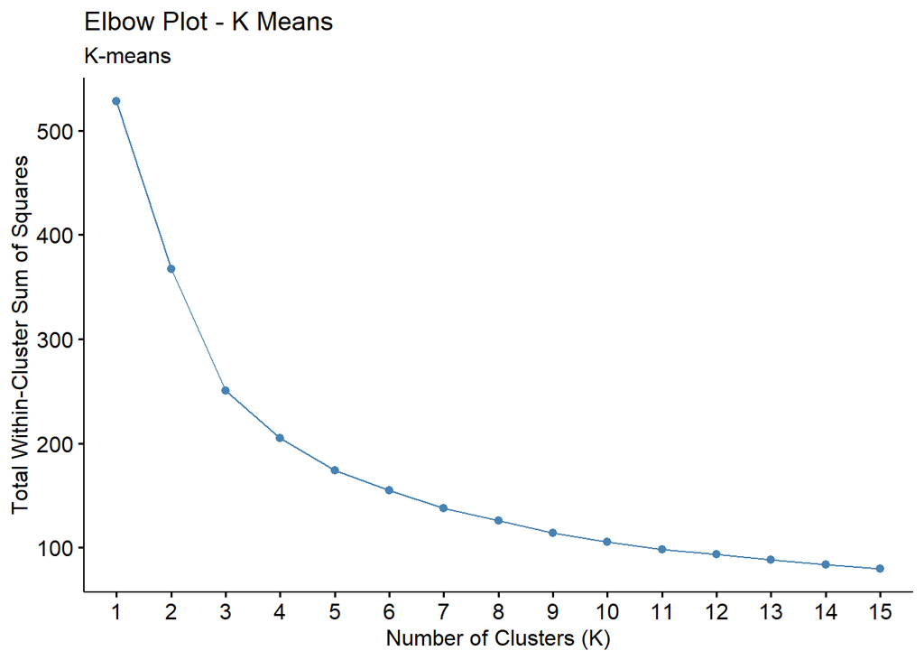

```r
  #Elbow plot
  set.seed(123)
  fviz_nbclust(x = CheeseScaled,
               FUNcluster = kmeans,
               method = "wss",
               k.max = 15,
               nstart = 25,
               iter.max = 15) +
    labs(subtitle = "K-means", title = "Elbow Plot - K Means",
         x = "Number of Clusters (K)",
         y = "Total Within-Cluster Sum of Squares")
```

```r
  set.seed(NULL)
```

Based on the elbow plot, the total within-cluster sum of squares decreases steadily as the number of clusters increases. While I would say there is no sharp “elbow” point, the rate of decrease begins to level off around K = 4. This suggests that increasing the number of clusters beyond 4 yields only marginal improvements in cluster compactness. Therefore, I would choose K = 4 as I believe it is a good balance between capturing the underlying structure in the data and maintaining model simplicity.

# Performing K-means with K = 4 and extract Total Within Cluster Variation

```r
  # Perform K-Means
  set.seed(123)
  kmeansCheese = kmeans(x = CheeseScaled, centers = 4, iter.max = 15, nstart = 25)
  kmeansCheese$tot.withinss
```

```
## [1] 204.9502
```

```r
  set.seed(NULL)
```

The total within-cluster variation (total WSS) for the K-means clustering solution with 4 clusters is 204.9502.

# Number of observations assigned to each cluster

```r
  # Finding how many observations are in each cluster
  kmeansCheese$size
```

```
## [1] 16 27 20 26
```

# Performing PCA and creating visualization for K = 4 (K-means)

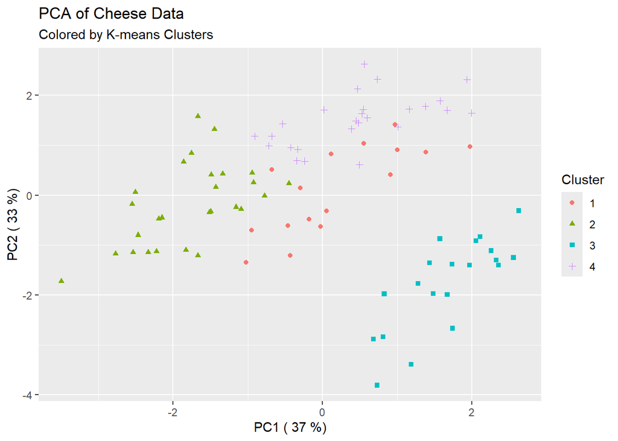

```r
  # Performing PCA
  CheesePCA = prcomp(x = CheeseScaled, center = TRUE, scale. = TRUE)
  PVE = CheesePCA$sdev^2 /sum(CheesePCA$sdev^2)

  # Creating a tempory data fram for plotting
  temp_df = as.data.frame(CheesePCA$x[,1:2])
  temp_df = temp_df %>%
    mutate(cluster = kmeansCheese$cluster)

  # Creating PCA of Pizza Data scatter plot
  ggplot(data = temp_df, mapping = aes(x = PC1, y = PC2,
                                       color = as.factor(cluster),
                                       shape = as.factor(cluster))) +
    geom_point() +
    labs(x = paste("PC1 (",round(100*PVE[1], digits = 1),"%)", sep = " "),
         y = paste("PC2 (",round(100*PVE[2], digits = 1),"%)", sep = " "),
         color = "Cluster", shape = "Cluster",
         title = "PCA of Cheese Data", subtitle = "Colored by K-means Clusters")
```

# Creating a two-way table

```r
  # Creating Two-Way Table for K-Means Clusters
  CheeseClust = Cheese %>%
    mutate(cluster = kmeansCheese$cluster)
  table(CheeseClust$texture, CheeseClust$cluster)
```

```
##
##                 1  2  3  4
##   Hard          0 19  0  4
##   Pasta Filata 14  0  0  8
##   Semi-Hard     2  8  0 14
##   Soft          0  0 20  0
```

The cluster analysis grouped cheese into clusters based on the composition of the features. Some clusters contain multiple textures (Cluster 1, 2, and 4), suggesting that those textures have similar profiles. Other clusters (Cluster 3) are dominated by a single texture, indicating distinctive characteristics. This mixture of overlap and separation shows that while textures differ, some share close similarities in their cheese composition.

# Performing Hierarchical Clustering

## Performing hierarchical clustering using Euclidean distance and complete linkage

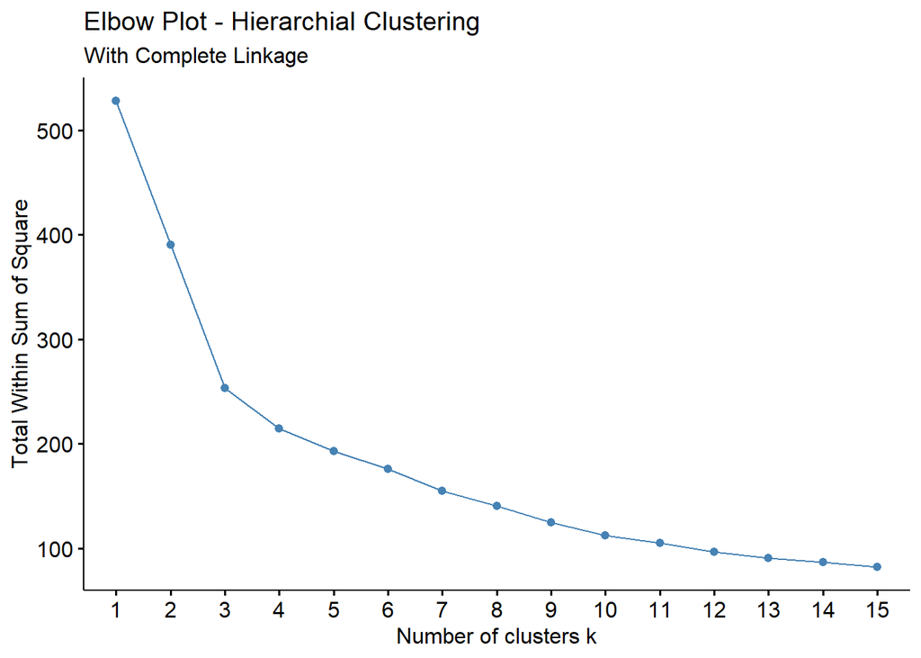

```r
  # Creating an Elbow Plot Using Hierarchical Clustering
  fviz_nbclust(x = CheeseScaled, FUNcluster = hcut,
               method = "wss",
               k.max = 15,
               hc_func = "hclust",
               hc_metric = "euclidean",
               hc_method = "complete") +
  labs(subtitle = "With Complete Linkage", title = "Elbow Plot - Hierarchial Clustering")
```

Based on the elbow plot, the total within-cluster sum of squares (WSS) shows a steep decline from K = 1 to K = 3 indicating substantial gains in cluster compactness as more clusters are added. Starting around K = 3, the rate of decrease in WSS begins to level off, suggesting diminishing returns in model improvement beyond this point. While there is no distinct or sharp “elbow,” the change in slope becomes more gradual at K = 3, making it a reasonable choice. Selecting K = 3 provides a good balance between capturing meaningful structure in the data and avoiding overfitting or unnecessary complexity in the model.

# Create a dendrogram and label clusters for K = 3

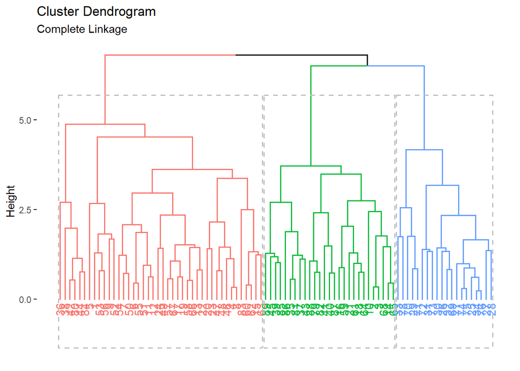

```r
  # Creating a Dendrogram
  eucDist = stats::dist(x = CheeseScaled, method = "euclidean")
  hcComplete = hclust(d = eucDist, method = "complete")
  fviz_dend(x = hcComplete, k = 3, rect = TRUE) + labs(subtitle = "Complete Linkage")
```

# Performing PCA and creating visualization for K = 3 (Hierarchical)

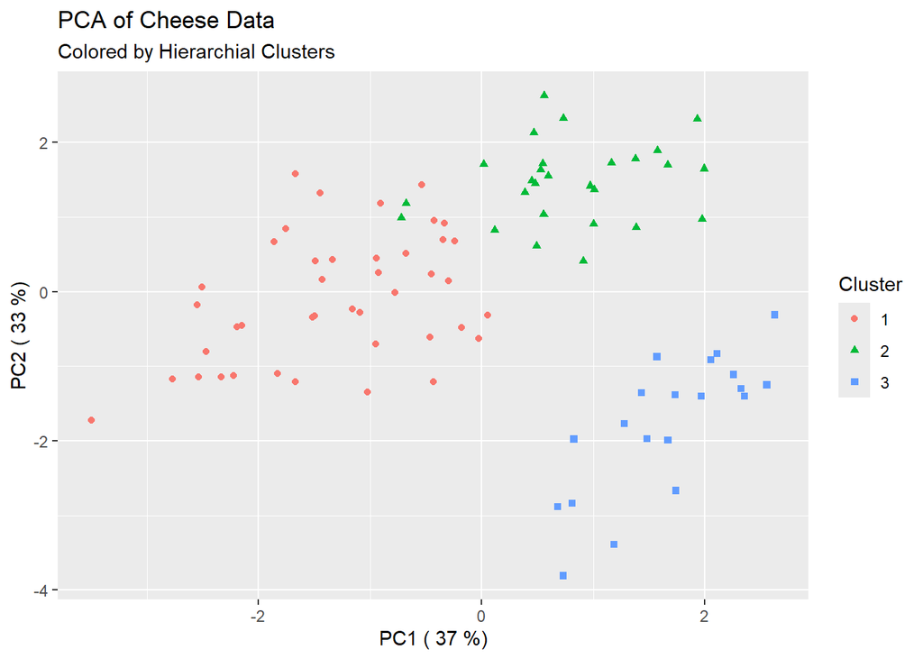

```r
  # Cutting the tree at K = 3
  hcClusters = cutree(hcComplete, k = 3)

  # Creating a Temporary Data Frame
  temp_df2 = as.data.frame(CheesePCA$x[, 1:2]) %>%
    mutate(cluster = as.factor(hcClusters))

  # Creating PCA of Pizza Data Scatter Plot
  ggplot(data = temp_df2, mapping = aes(x = PC1, y = PC2,
                                       color = as.factor(cluster),
                                       shape = as.factor(cluster))) +
    geom_point() +
    labs(x = paste("PC1 (",round(100*PVE[1], digits = 1),"%)", sep = " "),
         y = paste("PC2 (",round(100*PVE[2], digits = 1),"%)", sep = " "),
         color = "Cluster", shape = "Cluster",
         title = "PCA of Cheese Data", subtitle = "Colored by Hierarchial Clusters")
```

# Creating a two-way table

```r
  # Creating Two-Way Table for Hierarchial Clusters
  CheeseClustHier = Cheese %>%
    mutate(cluster = as.factor(hcClusters))
  table(CheeseClustHier$texture, CheeseClustHier$cluster)
```

```
##
##                 1  2  3
##   Hard         20  3  0
##   Pasta Filata  7 15  0
##   Semi-Hard    15  9  0
##   Soft          0  0 20
```

# Comparing K-means results to hierarchical results

Although both clustering methods used the same standardized variables, the difference in results can be attributed to the clustering strategy. K-means forms clusters by minimizing within-cluster variance, which tends to create compact, spherical clusters. Hierarchical clustering, on the other hand, especially with complete linkage, builds clusters by maximizing the distance between the most dissimilar observations, which can lead to more flexible and irregularly shaped clusters. This difference in methodology explains the variation in how textures were grouped between the two approaches.